# Different ways of using R

*Introduction to Bioinformatics - Module 2*

Nina Norgren

## Working with R

There are several ways to work with/in R:

- From a command line,
- In batch mode,
- From a native GUI,
- Using external editor, e.g. RStudio.

During this course, we will be focusing on working with [RStudio](https://www.rstudio.com)

## Working from command line

1. Open Terminal.
2. Type `R`.
3. Type R commands…
4. Type `q()` to quit R.
- Arrows to browse history
- Tab completion for typing commands

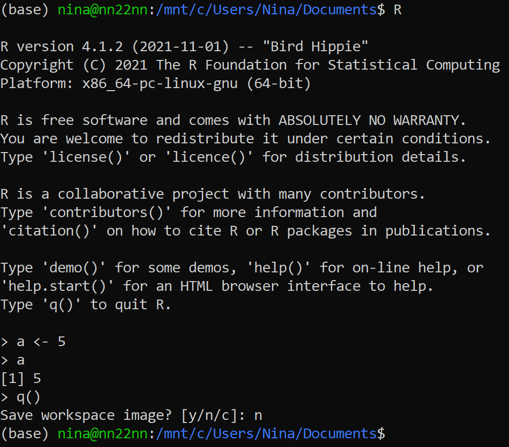

## The batch mode

- Bioinformatics analysis are often performed on a cluster
- Large/Many jobs might require a queue handling system
- Run R code from a file, using the so-called **batch mode**:
1. Create a file with your code and give it extension **.R**.
2. In the console (or in the queue script) write:

`R --vanilla < mycode.R`

## The batch mode

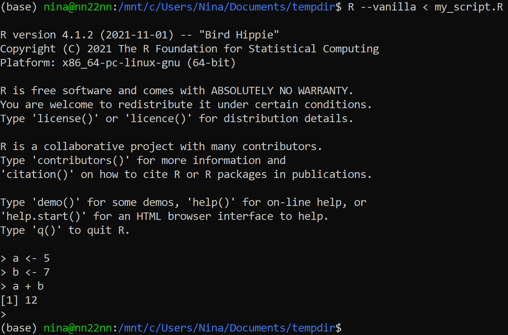

## Native GUI

1. Open R by double-clicking the R icon
2. A graphical interface will appear
3. You can enter commands in the console, and the GUI will display outputs

[figure not shown]

## Using RStudio

- Powerful editor for working with R code
- Consists of four panels:
  - Console, for running code
  - Editor, for writing code
  - Environment/History, for viewing environment variables and history
  - Files/Plots/Packages, for for example plot outputs

RStudio is the primary way of interacting with R during this course

## Using RStudio

[figure not shown]

## Getting help

Problems with installation or specific questions?

- Come see us in the exercise sessions

[Stackoverflow](http://stackoverflow.com) is also a great resource.